# Peer-graded Assignment: Course Project 1

Ashley Fowler

## Purpose/Data

This assignment makes use of data from a personal activity monitoring device. This device collects data at 5 minute intervals through out the day. The data consists of two months of data from an anonymous individual collected during the months of October and November, 2012 and include the number of steps taken in 5 minute intervals each day. The data for this assignment was downloaded from the course web site:

- Dataset: [Activity monitoring data](https://d396qusza40orc.cloudfront.net/repdata%2Fdata%2Factivity.zip) [52K]

The variables included in this dataset are:

- **steps**: Number of steps taking in a 5-minute interval (missing values are coded as `NA`)
- **date**: The date on which the measurement was taken in YYYY-MM-DD format
- **interval**: Identifier for the 5-minute interval in which measurement was taken

## Loading required package

Unzip data to obtain a csv file

```r
library(ggplot2)
library(plyr)
library(lattice)
```

Download Data

```r
data <- read.csv("activity.csv")
```

## Processing the Data

Correcting the type of date

```r
data$day <- weekdays(as.Date(data$date))
data$DateTime<- as.POSIXct(data$date, format="%Y-%m-%d")
```

Deleting NAs

```r
elimNas <- data[!is.na(data$steps),]
```

## What is the mean total number of steps taken per day?

Calculate the total number of steps taken per day

```r
TotalSteps <- tapply(data$steps, data$date, sum, na.rm = TRUE)
```

Create a Histogram of total steps taken per day

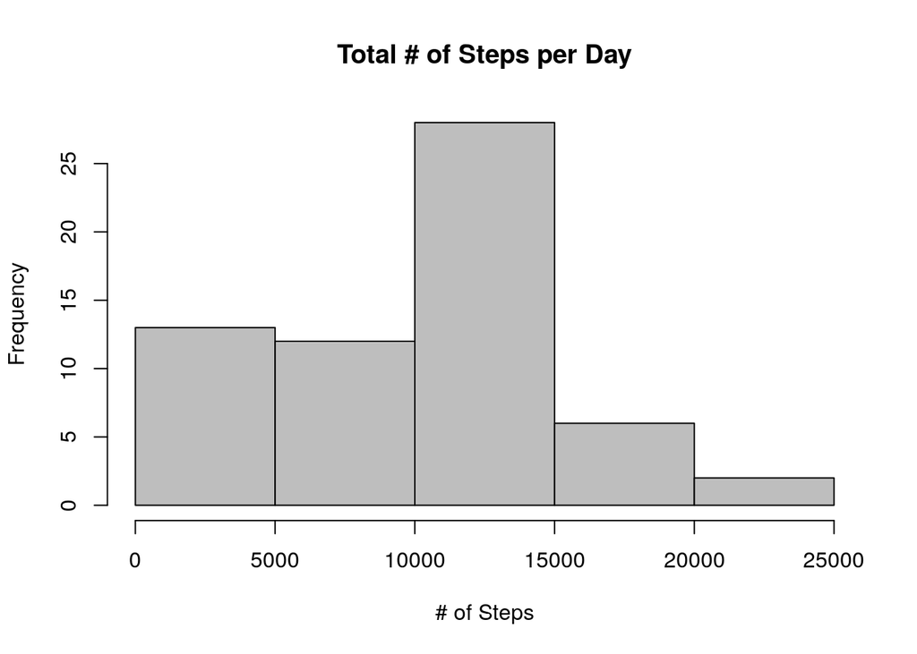

```r
hist(TotalSteps, xlab = "# of Steps", main = "Total # of Steps per Day", col="Grey")
```

Calculate Mean and Median of Total Steps

```r
mean(TotalSteps, na.rm = TRUE)
```

```
## [1] 9354.23
```

```r
median(TotalSteps, na.rm = TRUE)
```

```
## [1] 10395
```

## What is the average daily activity pattern?

Avg daily activity pattern

```r
AvgDaily <- ddply(elimNas, .(interval), summarize, AvgS = mean(steps))
```

Plot of average number of steps per interval

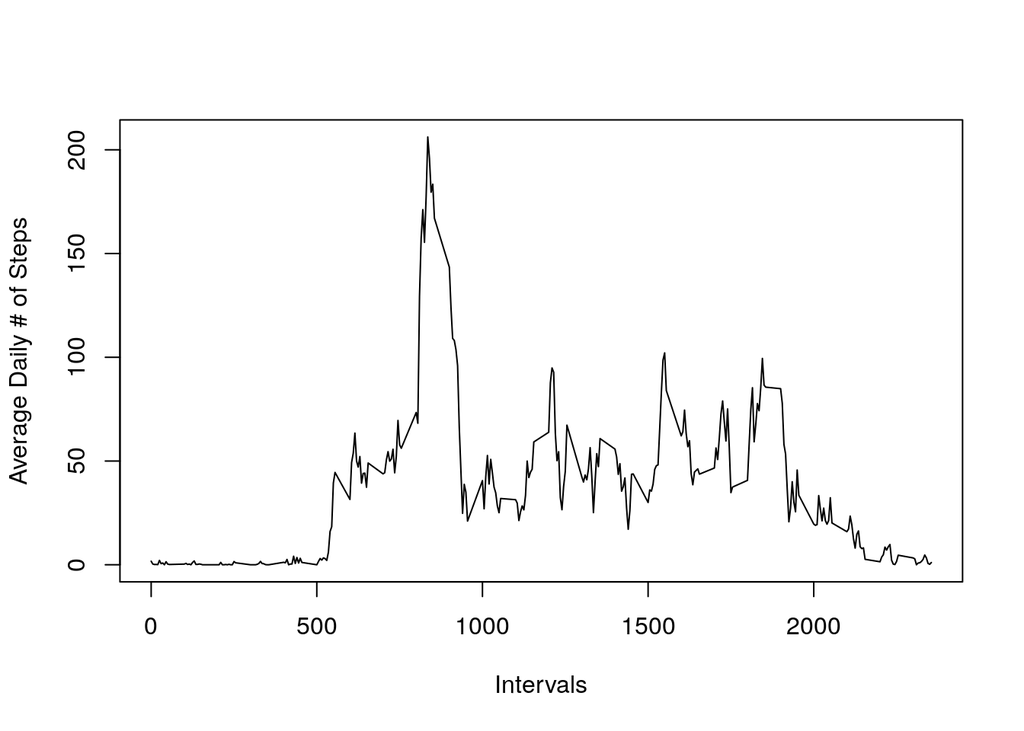

```r
with(AvgDaily,
     plot(interval,
          AvgS,
          type="l",
          xlab="Intervals",
          ylab="Average Daily # of Steps"))
```

## Which 5-minute interval, on average across all the days in the dataset, contains the maximum number of steps?

```r
AvgDailyMax <- max(AvgDaily$AvgS)
AvgDaily[AvgDaily$AvgS == AvgDailyMax, 1]
```

```
## [1] 835
```

## Missing Values

Calculate and report the total number of missing values in the dataset

```r
sum(is.na(data$steps))
```

```
## [1] 2304
```

Filling in all missing values in the dataset Compute average number of steps per weekday

```r
avgWeekday <- ddply(elimNas, .(interval, day), summarize, Avg = mean(steps))
```

Create dataset with all NAs for substitution

```r
NAs <- data[is.na(data$steps),]
```

Merge data

```r
mergedData <- merge(NAs, avgWeekday , by = c("interval", "day"))
```

Merge non NA data with NA data

```r
mergedData2 <- mergedData[,c(6,4,1,2,5)]
colnames(mergedData2)<- c("steps", "date", "interval", "day", "DateTime")

officialData <- rbind(elimNas, mergedData2)
```

Make a histogram of the total number of steps taken each day and Calculate and report the mean and median total number of steps taken per day

Create new sum of official data

```r
TotalSteps2 <- aggregate(officialData$steps ~ officialData$date, FUN=sum, )
colnames(TotalSteps2)<- c("Date", "Steps")
```

Recalculate mean and median with official data

```r
mean(TotalSteps2$Steps)
```

```
## [1] 10821.21
```

```r
median(TotalSteps2$Steps)
```

```
## [1] 11015
```

Histogram

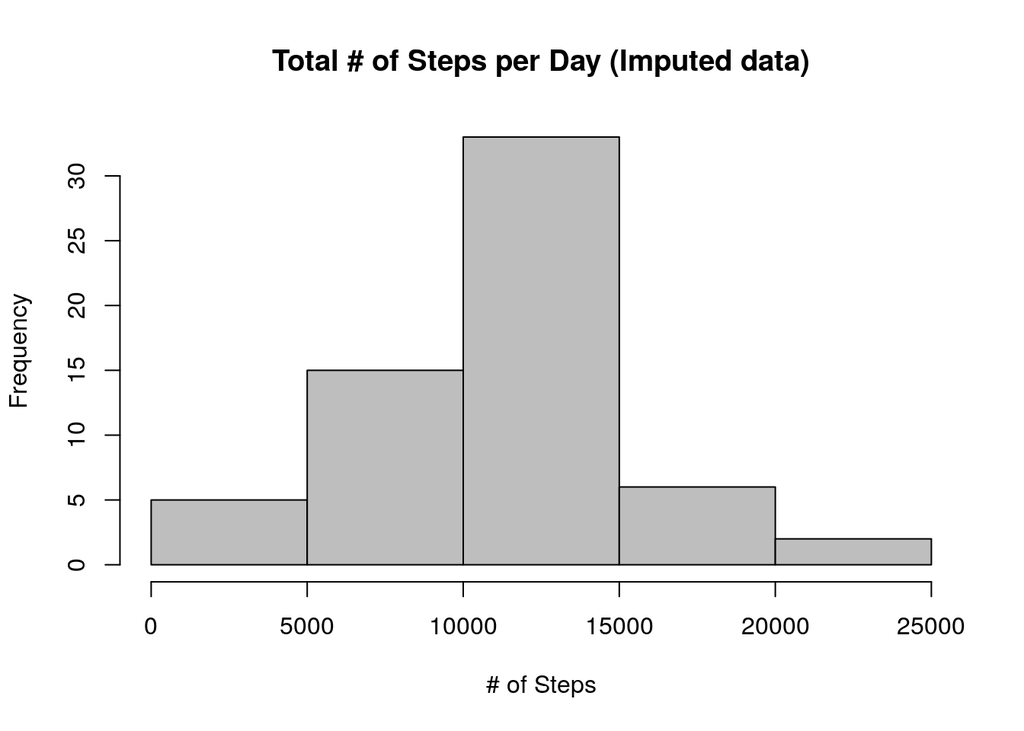

```r
hist(TotalSteps2$Steps, breaks=5, xlab="# of Steps", main = "Total # of Steps per Day (Imputed data)", col="Grey")
```

## Are there differences in activity patterns between weekdays and weekends?

New category for weekday and weekend

```r
officialData$NewCat <- ifelse(officialData$day %in% c("Saturday", "Sunday"), "Weekend", "Weekday")


mergedData3 <- ddply(officialData, .(interval, NewCat), summarize, Avg = mean(steps))
```

Plot data in a panel plot

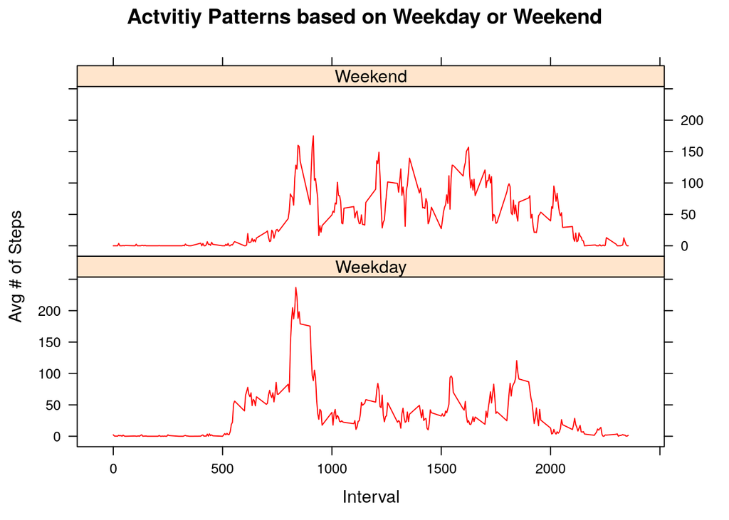

```r
xyplot(Avg~interval|NewCat, data = mergedData3, layout = c(1,2), type = "l",
       main = "Actvitiy Patterns based on Weekday or Weekend",
       ylab = "Avg # of Steps", xlab="Interval", col="Red")
```